LAPORAN PRAKTIKUM METODE STATISTIKA

| Dosen: | Asisten: |
| --- | --- |
| Dr. Epha Diana Supandi, S.Si, M.Si. | 1. Hanifah Rahmawati |
|  | 2. Yogi Anggara |

# Tugas 1

30/3/2021

# Soal 1

Diketahui matriks dimana kolom pertama Nama, kolom kedua Umur, kolom ketiga Jenis Kelamin dan kolom keempat Berat Badan dengan elemen – elemen berikut ini:

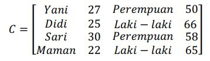

<sub>*Source: Modul Praktikum Metstat, hlm: 12*</sub>

## Bagian a

Buatlah matriks C dengan R!

```r
C = matrix(data=c("Yani", 27, "Perempuan", 50,
                  "Didi", 25, "Laki-laki", 66,
                  "Sari", 30, "Perempuan", 58,
                  "Maman", 22, "Laki-laki", 65),
           dimnames=list(c(), c("Nama", "Umur", "Jenis Kelamin", "Nilai")),
           nrow=4, ncol=4, byrow=TRUE)
C
```

```
##      Nama    Umur Jenis Kelamin Nilai
## [1,] "Yani"  "27" "Perempuan"   "50"
## [2,] "Didi"  "25" "Laki-laki"   "66"
## [3,] "Sari"  "30" "Perempuan"   "58"
## [4,] "Maman" "22" "Laki-laki"   "65"
```

## Bagian b

Lakukan ekstrasi matriks C, dimana matriks baru hanya berisi elemen yang umurnya kurang dari 25 tahun atau berat badannya kurang dari 60 $kg$!

```r
subset(C, C[,2] < 25 | C[,4] < 60)
```

```
##      Nama    Umur Jenis Kelamin Nilai
## [1,] "Yani"  "27" "Perempuan"   "50"
## [2,] "Sari"  "30" "Perempuan"   "58"
## [3,] "Maman" "22" "Laki-laki"   "65"
```

# Soal 2

PT. METSTAT ingin mengetahui apakah iklan yang mereka pasang memberi daya tarik pengguna untuk membeli produk atau tidak. Dari tim marketing, diperoleh data sebagai berikut:

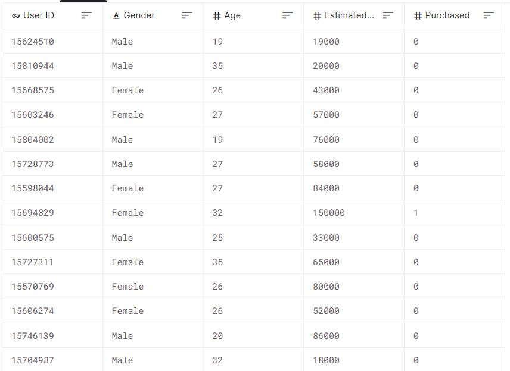

<sub>*Source: https://www.kaggle.com/rakeshrau/social-network-ads*</sub>

Dengan data tersebut, bantulah manajer PT. METSTAT untuk menentukan:

Note:  
- Import data di `data/Social_Network_Ads.csv`  
- Pada kolom `Purchased`: 1 = terbeli, 0 = tidak membeli  
- untuk mengurutkan data, gunakan `order` (lihat di fitur help)

## Bagian a

Tampilkan **data transaksi** (seluruh kolom) berupa 5 data gaji terkecil pengguna dengan usia antara 20 - 30 tahun yang membeli produk tersebut! (20 dan 30 tidak termasuk)

```r
df = read.csv("data/Social_Network_Ads.csv")
df.filtered = subset(df, Age > 20 & Age < 30 & Purchased == 1)
df.sort = df.filtered[order(df.filtered$EstimatedSalary), ]
head(df.sort)
```

|  | User.ID | Gender | Age | EstimatedSalary | Purchased |
| --- | --- | --- | --- | --- | --- |
| 147 | 15750839 | Female | 27 | 96000 | 1 |
| 98 | 15582492 | Male | 28 | 123000 | 1 |
| 32 | 15729054 | Female | 27 | 137000 | 1 |
| 169 | 15789815 | Male | 29 | 148000 | 1 |